# Introduction to Deep Learning

## Intoduction to Deep Learning in Python

Alicja Wilk

Tutorial based on DataCamp course : https://www.datacamp.com/courses/deep-learning-in-python

Deep Learning is part of Machine Learning and Artificial Inteligence. Deep Learning uses **Artificial Neural Networks** inspired by brains neurons to come up with desired predictions. Deep Learning is a broad area that has a lot of different applications in different industries. In this tutorial, you will be introduced to a few simple examples of Neural Networks. It is desirable that you research more conceptually before attmpting to run the examples.

Each data point is a customer. Input data shows how many children and accounts open the customer has. We are predicting number of transactions the user will make next year.

#### Creating a simple prediction NN

```python
import numpy as np

input_data = np.array([3,5])

weights = {'node_0': np.array([2,4]),
           'node_1': np.array([4,-5]),
           'output': np.array([2,7])
          }

node_0_value = (input_data * weights['node_0']).sum()
node_1_value = (input_data * weights['node_1']).sum()
hidden_layer_outputs = ([node_0_value, node_1_value])
output = (hidden_layer_outputs * weights['output']).sum()
```

```python
print(input_data)
print(weights)
print(hidden_layer_outputs)
print(output)
```

```
[3 5]
{'node_0': array([2, 4]), 'node_1': array([ 4, -5]), 'output': array([2, 7])}
[26, -13]
-39
```

#### The Rectified Linear Activation Function

Activation Functions are functions applied at each node to convert nodes input into output.

ReLU function - shown to lead to very high performance networks.

The functions take a sigle number as input, if number is positive it returns the input number, if number is negative it returns 0.

Example:

- relu(3) = 3
- relu(-5) = 0

Weights in NN are set during the model trainng process to optimize predictive accuracy.

```python
# Define function ReLU

def relu(input):
    '''Define your relu activation function here'''
    output = max(0, input)

    return(output)
```

```python
# Calculate node 0 value: node_0_output
node_0_input = (input_data * weights['node_0']).sum()
node_0_output = relu(node_0_input)

# Calculate node 1 value: node_1_output
node_1_input = (input_data * weights['node_1']).sum()
node_1_output = relu(node_1_input)
```

```python
# Define predict_with_network()
def predict_with_network(input_data_row, weights):

    # Calculate node 0 value
    node_0_input = (input_data_row * weights['node_0']).sum()
    node_0_output = relu(node_0_input)

    # Calculate node 1 value
    node_1_input = (input_data_row * weights['node_1']).sum()
    node_1_output = relu(node_1_input)

    # Put node values into array: hidden_layer_outputs
    hidden_layer_outputs = np.array([node_0_output, node_1_output])

    # Calculate model output
    input_to_final_layer = (hidden_layer_outputs * weights['output']).sum()
    model_output = relu(input_to_final_layer)

    # Return model output
    return(model_output)


# Create empty list to store prediction results
results = []
for input_data_row in input_data:
    # Append prediction to results
    results.append(predict_with_network(input_data_row,weights))

# Print results
print(results)
```

```
[36, 60]
```

Big breakthrough in deep learning is using **multiple hidden layers** as opposed to only one hidden layer.

Many hidden layers:

- use values from a previous hidden layers to fill in values in the next hidden layer. We use activation function ReLU at each node.
- a few years ago state of the art was 15 hidden layers but now it can easily scale out to 1000 hidden layers

Deep Learning is a Representation Learning :

- deep network internally builds representations of patterns in the data
- it partially removes the need for feature engineering

In Deep Learning the modeler does not need to specify the interactions or tell the model what to look for. Training model gets weights to find relevant patterns in the data to make better predictions.

The last layer of the interaction captures the most high - level interactions.

#### Multi-layer neural networks

```python
# creating the data

input_data = np.array([3,5])
weights = {
    'node_0_0': np.array([2,4]),
    'node_0_1': np.array([4,-5]),
    'node_1_0': np.array([-1,2]),
    'node_1_1': np.array([1,2]),
    'output'  : np.array([2,7])
}
```

```python
def predict_with_network(input_data):
    # Calculate node 0 in the first hidden layer
    node_0_0_input = (input_data * weights['node_0_0']).sum()
    node_0_0_output = relu(node_0_0_input)

    # Calculate node 1 in the first hidden layer
    node_0_1_input = (input_data * weights['node_0_1']).sum()
    node_0_1_output = relu(node_0_1_input)

    # Put node values into array: hidden_0_outputs
    hidden_0_outputs = np.array([node_0_0_output, node_0_1_output])

    # Calculate node 0 in the second hidden layer
    node_1_0_input = (hidden_0_outputs * weights['node_1_0']).sum()
    node_1_0_output = relu(node_1_0_input)

    # Calculate node 1 in the second hidden layer
    node_1_1_input = (hidden_0_outputs * weights['node_1_1']).sum()
    node_1_1_output = relu(node_1_1_input)

    # Put node values into array: hidden_1_outputs
    hidden_1_outputs = np.array([node_1_0_output, node_1_1_output])

    # Calculate model output: model_output
    model_output = (hidden_1_outputs * weights['output']).sum()

    # Return model_output
    return(model_output)

output = predict_with_network(input_data)
print(output)
```

```
182
```

**Loss Function**

- aggregate all errors from all prediciton data points into a single number
- measures model performance

Goal: Find weights that give the lowest value for the loss function.

- Gradient Descent is best choice for Naural Network models

#### Coding how weight changes affect accuracy

```python
input_data = np.array([0,3])

def predict_with_network_2(input_data, weights):
    # Calculate node 0 value
    node_0_input =  (input_data * weights['node_0']).sum()
    node_0_output = relu(node_0_input)

    # Calculate node 1 value
    node_1_input = (input_data * weights['node_1']).sum()
    node_1_output = relu(node_1_input)

    # Put node values into array: hidden_layer_outputs
    hidden_layer_outputs = np.array([node_0_output, node_1_output])

    # Calculate model output
    input_to_final_layer = (hidden_layer_outputs * weights['output']).sum()
    model_output = relu(input_to_final_layer)

    # Return model output
    return(model_output)


# The data point you will make a prediction for
input_data = np.array([0, 3])

# Sample weights
weights_0 = {'node_0': [2, 1],
             'node_1': [1, 2],
             'output': [1, 1]
            }

# The actual target value, used to calculate the error
target_actual = 3

# Make prediction using original weights
model_output_0 = predict_with_network_2(input_data, weights_0)

# Calculate error: error_0
error_0 = model_output_0 - target_actual

# Create weights that cause the network to make perfect prediction (3): weights_1
weights_1 = {'node_0': [2, 1],
             'node_1': [1, 0],
             'output': [1, 1]
            }

# Make prediction using new weights: model_output_1
model_output_1 = predict_with_network_2(input_data, weights_1)

# Calculate error: error_1
error_1 = model_output_1 - target_actual

# Print error_0 and error_1
print(error_0)
print(error_1)
```

```
6
0
```

#### Scaling up to multiple data points

Compare model accuracy on different set of weights on all data points.

```python
from sklearn.metrics import mean_squared_error

input_data = np.array([[0, 3] , [1, 2], [-1, -2], [4, 0]])
target_actuals = [1, 3, 5, 7]

weights_0 = {'node_0': [2, 1],
             'node_1': [1, 2],
             'output': [1, 1]
            }

weights_1 = {'node_0': [2, 1],
             'node_1': [1. , 1.5],
             'output': [1. , 1.5]
            }

# Create model_output_0
model_output_0 = []
# Create model_output_1
model_output_1 = []

# Loop over input_data
for row in input_data:
    # Append prediction to model_output_0
    model_output_0.append(predict_with_network_2(row, weights_0))

    # Append prediction to model_output_1
    model_output_1.append(predict_with_network_2(row, weights_1))

# Calculate the mean squared error for model_output_0: mse_0
mse_0 = mean_squared_error(target_actuals, model_output_0)

# Calculate the mean squared error for model_output_1: mse_1
mse_1 = mean_squared_error(target_actuals, model_output_1)

# Print mse_0 and mse_1
print("Mean squared error with weights_0: %f" %mse_0)
print("Mean squared error with weights_1: %f" %mse_1)
```

```
Mean squared error with weights_0: 37.500000
Mean squared error with weights_1: 49.890625
```

### Gradient Descent

- finding the most optimized loss function.
- going opposite the slope means moving to lower numbers
- too big steps might make us miss the optimized point - that's why we use **Learning Rate**.
  - update each weight by substracting **learning rate * slope**

#### Slope calculation example

To calculate slope we need to multiply:

- Slope of the loss function w.r.t value at the node we feed into(Slope of mean-squared loss function w.r.t prediction):
  - weights *(Predicted Value - Actual Value) = 2* Error
  - weights * -4
- The value of the node that feeds into our weight
- Slope of the activation function w.r.t value we feed into ( leave this out if there is no activation function)

Now we update in regards to the learning rate :

- if learning rate = 0.01 then the new weigth would be **weights - 0.01(slope)**

```python
import numpy as np
weights = np.array([0,2,1])
input_data = np.array([1,2,3])
weigths = np.array([0,2,1])
target = 0

# Calculate the predictions: preds
preds = (weights * input_data).sum()

# Calculate the error: error
error = preds - target

# Calculate the slope: slope
slope = 2 * input_data * error

# Print the slope
print(slope)
```

```
[14 28 42]
```

#### Improving model weights through learning rate

```python
# Set the learning rate: learning_rate
learning_rate = 0.01

# Calculate the predictions: preds
preds = (weights * input_data).sum()

# Calculate the error: error
error = preds - target

# Calculate the slope: slope
slope = 2 * input_data * error
# Update the weights: weights_updated
weights_updated = weights - (learning_rate * slope)

# Get updated predictions: preds_updated
preds_updated = (input_data * weights_updated).sum()

# Calculate updated error: error_updated
error_updated = preds_updated - target

# Print the original error
print(error)

# Print the updated error
print(error_updated)
```

```
7
5.04
```

#### Making multiple updates to weights -> _GETTING WEIRD RESULTS NOT WHAT I AM GETTING AT DATACAMP__

```python
def get_error(input_data, target, weights):
    preds = (weights * input_data).sum()
    error = preds - target
    return(error)

def get_slope(input_data, target, weights):
    get_error(input_data, target, weights)
    slope = 2 * input_data * error # weights or 2 ??
    return(slope)

def get_mse(input_data, target, weights):
    errors = get_error(input_data, target, weights)
    mse = np.mean(errors**2)
    return(mse)

n_updates = 20
mse_hist = []
input_data = np.array([1,2,3])
weights = np.array([0.5, 1, 0.5])
target = 0

# Iterate over the number of updates
for i in range(n_updates):
    # Calculate the slope: slope
    slope = get_slope(input_data, target, weights)

    # Update the weights: weights
    weights = weights - 0.01 * slope

    # Calculate mse with new weights: mse
    mse = get_mse(input_data, target, weights)

    # Append the mse to mse_hist
    mse_hist.append(mse)
```

```python
import matplotlib.pyplot as plt

# Plot the mse history
plt.plot(mse_hist)
plt.xlabel('Iterations')
plt.ylabel('Mean Squared Error')
plt.show()
```

[output not shown]

## Backpropagation

Backpragation takes the output layer error and propagates it backwords through the hidden layers towards the input layer.

- frirst, gradient descent updates all weights in neural network
- comes from chain rule of calculus
- complex math but what's more important - understand the process bc you will use library to do the math(duh)
- always do forward propagation first before we do backward propagation

#### Backpropagation process

- Go back one layer at a time
- Gradients for weight is product of:
  1. Node value feeding into that weight
  2. Slope of loss function w.r.t node it feeds into
  3. Slope of activation function at the node it feeds into

### Backpropagation: Recap

1. Start at some random set of weights
2. Use forward propagation to make a prediction
3. Use backward propagation to calculate the slope of the loss function w.r.t each weight
4. Multiply that slope by the learning rate, and subtract from the current weights
5. Keep going with that cycle until we get to a flat part

### Stochastic gradient descent

- It is common to calculate slopes on only a subset of the data (‘batch’)
- Use a different batch of data to calculate the next update
- Start over from the beginning once all data is used Each time through the training data is called an epoch
- When slopes are calculated on one batch at a time: stochastic gradient descent

## Creating a Keras Model - Regression

```python
import pandas as pd
df = pd.read_csv('https://assets.datacamp.com/production/repositories/654/datasets/8a57adcdb5bfb3e603dad7d3c61682dfe63082b8/hourly_wages.csv')
predictors = np.array(df[['union','education_yrs','age','female','marr','south','manufacturing','construction']])
target = np.array(df['wage_per_hour'])
```

```python
# Import necessary modules
import keras
from keras.layers import Dense
from keras.models import Sequential

# Save the number of columns in predictors: n_cols
n_cols = predictors.shape[1]

# Set up the model: model
model = Sequential()

# Add the first layer
model.add(Dense(50, activation='relu', input_shape=(n_cols,)))

# Add the second layer
model.add(Dense(32, activation='relu'))

# Add the output layer
model.add(Dense(1))
```

[output not shown]

### Compailing and fitting the model

To compile the model, you need to specify the optimizer and loss function to use.

Specify optimizer : 'Adam' is usually a good choice. \ Loss - function : MSE for Regression models

Fitting the model: Applying backpropagation and gradient descent with your data to update the weights

**Scaling data before fitting can ease optimization**

```python
# Compile the model
model.compile(optimizer = 'adam', loss='mean_squared_error', metrics=None, loss_weights=None, sample_weight_mode=None, weighted_metrics=None, target_tensors=None)

# Verify that model contains information from compiling
print("Loss function: " + model.loss)
```

```
Loss function: mean_squared_error
```

```python
fitted_model = model.fit(predictors, target)
```

[output not shown]

## Creating a Keras Model - Classification

```python
import pandas as pd
from keras.utils import to_categorical

df = pd.read_csv('https://assets.datacamp.com/production/repositories/654/datasets/92b75b9bc0c0a8a30999d76f4a1ee786ef072a9c/titanic_all_numeric.csv')
predictors = df.drop(['survived'], axis = 1).as_matrix()
n_cols = predictors.shape[1]
```

```python
# Import necessary modules
import keras
from keras.layers import Dense
from keras.models import Sequential
from keras.utils import to_categorical

# Convert the target to categorical: target
target = to_categorical(df.survived)

# Set up the model
model = Sequential()

# Add the first layer
model.add(Dense(32, activation='relu', input_shape=(n_cols,)))

# Add the output layer
model.add(Dense(2, activation='softmax'))

# Compile the model
model.compile(optimizer='sgd',
              loss='categorical_crossentropy',
              metrics=['accuracy'])

# Fit the model
model.fit(predictors, target)
```

```
<keras.callbacks.callbacks.History at 0x1a371ae940>
```

```python
# Data from Data Camp
pred_data = np.array([
        [2, 34.0, 0, 0, 13.0, 1, False, 0, 0, 1],
        [2, 31.0, 1, 1, 26.25, 0, False, 0, 0, 1],
       [1, 11.0, 1, 2, 120.0, 1, False, 0, 0, 1],
       [3, 0.42, 0, 1, 8.5167, 1, False, 1, 0, 0],
       [3, 27.0, 0, 0, 6.975, 1, False, 0, 0, 1],
       [3, 31.0, 0, 0, 7.775, 1, False, 0, 0, 1],
       [1, 39.0, 0, 0, 0.0, 1, False, 0, 0, 1],
       [3, 18.0, 0, 0, 7.775, 0, False, 0, 0, 1],
       [2, 39.0, 0, 0, 13.0, 1, False, 0, 0, 1],
       [1, 33.0, 1, 0, 53.1, 0, False, 0, 0, 1],
       [3, 26.0, 0, 0, 7.8875, 1, False, 0, 0, 1],
       [3, 39.0, 0, 0, 24.15, 1, False, 0, 0, 1],
       [2, 35.0, 0, 0, 10.5, 1, False, 0, 0, 1],
       [3, 6.0, 4, 2, 31.275, 0, False, 0, 0, 1],
       [3, 30.5, 0, 0, 8.05, 1, False, 0, 0, 1],
       [1, 29.69911764705882, 0, 0, 0.0, 1, True, 0, 0, 1],
       [3, 23.0, 0, 0, 7.925, 0, False, 0, 0, 1],
       [2, 31.0, 1, 1, 37.0042, 1, False, 1, 0, 0],
       [3, 43.0, 0, 0, 6.45, 1, False, 0, 0, 1],
       [3, 10.0, 3, 2, 27.9, 1, False, 0, 0, 1],
       [1, 52.0, 1, 1, 93.5, 0, False, 0, 0, 1],
       [3, 27.0, 0, 0, 8.6625, 1, False, 0, 0, 1],
       [1, 38.0, 0, 0, 0.0, 1, False, 0, 0, 1],
       [3, 27.0, 0, 1, 12.475, 0, False, 0, 0, 1],
       [3, 2.0, 4, 1, 39.6875, 1, False, 0, 0, 1],
       [3, 29.69911764705882, 0, 0, 6.95, 1, True, 0, 1, 0],
       [3, 29.69911764705882, 0, 0, 56.4958, 1, True, 0, 0, 1],
       [2, 1.0, 0, 2, 37.0042, 1, False, 1, 0, 0],
       [3, 29.69911764705882, 0, 0, 7.75, 1, True, 0, 1, 0],
       [1, 62.0, 0, 0, 80.0, 0, False, 0, 0, 0],
       [3, 15.0, 1, 0, 14.4542, 0, False, 1, 0, 0],
       [2, 0.83, 1, 1, 18.75, 1, False, 0, 0, 1],
       [3, 29.69911764705882, 0, 0, 7.2292, 1, True, 1, 0, 0],
       [3, 23.0, 0, 0, 7.8542, 1, False, 0, 0, 1],
       [3, 18.0, 0, 0, 8.3, 1, False, 0, 0, 1],
       [1, 39.0, 1, 1, 83.1583, 0, False, 1, 0, 0],
       [3, 21.0, 0, 0, 8.6625, 1, False, 0, 0, 1],
       [3, 29.69911764705882, 0, 0, 8.05, 1, True, 0, 0, 1],
       [3, 32.0, 0, 0, 56.4958, 1, False, 0, 0, 1],
       [1, 29.69911764705882, 0, 0, 29.7, 1, True, 1, 0, 0],
       [3, 20.0, 0, 0, 7.925, 1, False, 0, 0, 1],
       [2, 16.0, 0, 0, 10.5, 1, False, 0, 0, 1],
       [1, 30.0, 0, 0, 31.0, 0, False, 1, 0, 0],
       [3, 34.5, 0, 0, 6.4375, 1, False, 1, 0, 0],
       [3, 17.0, 0, 0, 8.6625, 1, False, 0, 0, 1],
       [3, 42.0, 0, 0, 7.55, 1, False, 0, 0, 1],
       [3, 29.69911764705882, 8, 2, 69.55, 1, True, 0, 0, 1],
       [3, 35.0, 0, 0, 7.8958, 1, False, 1, 0, 0],
       [2, 28.0, 0, 1, 33.0, 1, False, 0, 0, 1],
       [1, 29.69911764705882, 1, 0, 89.1042, 0, True, 1, 0, 0],
       [3, 4.0, 4, 2, 31.275, 1, False, 0, 0, 1],
       [3, 74.0, 0, 0, 7.775, 1, False, 0, 0, 1],
       [3, 9.0, 1, 1, 15.2458, 0, False, 1, 0, 0],
       [1, 16.0, 0, 1, 39.4, 0, False, 0, 0, 1],
       [2, 44.0, 1, 0, 26.0, 0, False, 0, 0, 1],
       [3, 18.0, 0, 1, 9.35, 0, False, 0, 0, 1],
       [1, 45.0, 1, 1, 164.8667, 0, False, 0, 0, 1],
       [1, 51.0, 0, 0, 26.55, 1, False, 0, 0, 1],
       [3, 24.0, 0, 3, 19.2583, 0, False, 1, 0, 0],
       [3, 29.69911764705882, 0, 0, 7.2292, 1, True, 1, 0, 0],
       [3, 41.0, 2, 0, 14.1083, 1, False, 0, 0, 1],
       [2, 21.0, 1, 0, 11.5, 1, False, 0, 0, 1],
       [1, 48.0, 0, 0, 25.9292, 0, False, 0, 0, 1],
       [3, 29.69911764705882, 8, 2, 69.55, 0, True, 0, 0, 1],
       [2, 24.0, 0, 0, 13.0, 1, False, 0, 0, 1],
       [2, 42.0, 0, 0, 13.0, 0, False, 0, 0, 1],
       [2, 27.0, 1, 0, 13.8583, 0, False, 1, 0, 0],
       [1, 31.0, 0, 0, 50.4958, 1, False, 0, 0, 1],
       [3, 29.69911764705882, 0, 0, 9.5, 1, True, 0, 0, 1],
       [3, 4.0, 1, 1, 11.1333, 1, False, 0, 0, 1],
       [3, 26.0, 0, 0, 7.8958, 1, False, 0, 0, 1],
       [1, 47.0, 1, 1, 52.5542, 0, False, 0, 0, 1],
       [1, 33.0, 0, 0, 5.0, 1, False, 0, 0, 1],
       [3, 47.0, 0, 0, 9.0, 1, False, 0, 0, 1],
       [2, 28.0, 1, 0, 24.0, 0, False, 1, 0, 0],
       [3, 15.0, 0, 0, 7.225, 0, False, 1, 0, 0],
       [3, 20.0, 0, 0, 9.8458, 1, False, 0, 0, 1],
       [3, 19.0, 0, 0, 7.8958, 1, False, 0, 0, 1],
       [3, 29.69911764705882, 0, 0, 7.8958, 1, True, 0, 0, 1],
       [1, 56.0, 0, 1, 83.1583, 0, False, 1, 0, 0],
       [2, 25.0, 0, 1, 26.0, 0, False, 0, 0, 1],
       [3, 33.0, 0, 0, 7.8958, 1, False, 0, 0, 1],
       [3, 22.0, 0, 0, 10.5167, 0, False, 0, 0, 1],
       [2, 28.0, 0, 0, 10.5, 1, False, 0, 0, 1],
       [3, 25.0, 0, 0, 7.05, 1, False, 0, 0, 1],
       [3, 39.0, 0, 5, 29.125, 0, False, 0, 1, 0],
       [2, 27.0, 0, 0, 13.0, 1, False, 0, 0, 1],
       [1, 19.0, 0, 0, 30.0, 0, False, 0, 0, 1],
       [3, 29.69911764705882, 1, 2, 23.45, 0, True, 0, 0, 1],
       [1, 26.0, 0, 0, 30.0, 1, False, 1, 0, 0],
       [3, 32.0, 0, 0, 7.75, 1, False, 0, 1, 0]])
```

```python
# Specify, compile, and fit the model
model = Sequential()
model.add(Dense(32, activation='relu', input_shape = (n_cols,)))
model.add(Dense(2, activation='softmax'))
model.compile(optimizer='sgd',
              loss='categorical_crossentropy',
              metrics=['accuracy'])
model.fit(predictors, target)

# Calculate predictions: predictions
predictions = model.predict(pred_data)

# Calculate predicted probability of survival: predicted_prob_true
predicted_prob_true = predictions[:,1]

# print predicted_prob_true
print(predicted_prob_true)
```

```
[0.05727787 0.10436364 0.99999845 0.5719514  0.08086148 0.05887859
 0.05298921 0.12769064 0.03748008 0.7314239  0.08910637 0.04007566
 0.05036625 0.908925   0.06169083 0.11371021 0.08599032 0.30059657
 0.02054872 0.80159634 0.967579   0.08324686 0.0572621  0.07755499
 0.98072916 0.07670823 0.8219595  0.9871127  0.07777843 0.30398136
 0.20337251 0.8613815  0.0683413  0.11321769 0.16727944 0.9875164
 0.13410252 0.06588873 0.76431555 0.24493758 0.14306964 0.22188248
 0.22654893 0.04506502 0.1810498  0.02287498 0.97308946 0.04433399
 0.29708803 0.9988355  0.9310177  0.0014124  0.43543297 0.9213371
 0.02349217 0.15009026 0.99999905 0.01946347 0.17716195 0.0683413
 0.02958235 0.1616066  0.01850698 0.97255546 0.1288594  0.02147146
 0.08409284 0.7435036  0.06758358 0.5196796  0.08911904 0.1956502
 0.06166331 0.01518351 0.12034025 0.16665916 0.14754646 0.15425692
 0.06571079 0.7033504  0.229829   0.0498651  0.09744098 0.08997728
 0.0952343  0.08754303 0.10174229 0.5971451  0.10376401 0.32980347
 0.06436209]
```

## Optimization

Stochastic Gradient Descent is a good choice ( what about the Mini Batch Gradient Descent)

Common challenge for relu activation function: the dying neuron problem : that happens when neuron takes a value of less than 0 for all rows of data

'Dead' Neuron - once node starts negative, it might continue only getting negative inputs. It contributes **nothing** to the model.

Common challenge for tanh activation function : 'Vanishin Gradients' - occurs when many layers have very small slopes, due to being on the flat part of the tanh curve.

Diagnosing optimization problems Which of the following could prevent a model from showing an improved loss in its first few epochs?

*Learning rate too low. Learning rate too high. Poor choice of activation function.*

```python
df = pd.read_csv('https://assets.datacamp.com/production/repositories/654/datasets/92b75b9bc0c0a8a30999d76f4a1ee786ef072a9c/titanic_all_numeric.csv')
predictors = df.drop(['survived'], axis = 1).as_matrix()
n_cols = predictors.shape[1]
input_shape = (n_cols,)

def get_new_model(input_shape = input_shape):
    model = Sequential()
    model.add(Dense(100, activation='relu', input_shape = input_shape))
    model.add(Dense(100, activation='relu'))
    model.add(Dense(2, activation='softmax'))
    return(model)
```

```python
# Import the SGD optimizer
from keras.optimizers import SGD

# Create list of learning rates: lr_to_test
lr_to_test = [.000001, 0.01, 1]

# Loop over learning rates
for lr in lr_to_test:
    print('\n\nTesting model with learning rate: %f\n'%lr )

    # Build new model to test, unaffected by previous models
    model = get_new_model()

    # Create SGD optimizer with specified learning rate: my_optimizer
    my_optimizer = SGD(lr = lr)

    # Compile
    model.compile(optimizer = my_optimizer, loss = 'categorical_crossentropy')

    # Fit
    model.fit(predictors, target)
```

```
Testing model with learning rate: 0.000001



Testing model with learning rate: 0.010000



Testing model with learning rate: 1.000000
```

## Model Validation

In Deep Learning k-fold is not a good option for validation. Repeated cross validation would take a long time.

In Keras we just use validation_split. Our Goal:

- keep trainig while validation scores are improving and stop training once validation scores are not improving anymore.
- to do so we use EarlyStopping monitor, and set in up in .fit as a list. Patience is how many epochs we tolerate to be disimproving.

```python
# Save the number of columns in predictors: n_cols
n_cols = predictors.shape[1]
input_shape = (n_cols,)

# Specify the model
model = Sequential()
model.add(Dense(100, activation='relu', input_shape = input_shape))
model.add(Dense(100, activation='relu'))
model.add(Dense(2, activation='softmax'))

# Compile the model
model.compile(optimizer = 'adam', loss = 'categorical_crossentropy', metrics =['accuracy'] )

# Fit the model
hist = model.fit(predictors, target, validation_split = 0.3)
```

```
Train on 623 samples, validate on 268 samples
```

```python
# Import EarlyStopping
from keras.callbacks import EarlyStopping

# Save the number of columns in predictors: n_cols
n_cols = predictors.shape[1]
input_shape = (n_cols,)

# Specify the model
model = Sequential()
model.add(Dense(100, activation='relu', input_shape = input_shape))
model.add(Dense(100, activation='relu'))
model.add(Dense(2, activation='softmax'))

# Compile the model
model.compile(optimizer='adam', loss='categorical_crossentropy', metrics=['accuracy'])

# Define early_stopping_monitor
early_stopping_monitor = EarlyStopping(patience=2)

# Fit the model
model.fit(predictors, target, epochs=30, validation_split=0.3, callbacks=[early_stopping_monitor])
```

```
Train on 623 samples, validate on 268 samples
```

```
<keras.callbacks.callbacks.History at 0x1a3971db00>
```

#### Experimenting with wider networks

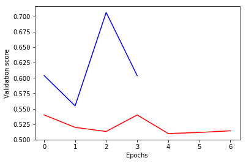

```python
# Define early_stopping_monitor
early_stopping_monitor = EarlyStopping(patience=2)

# Create the new model: model_1
model_1 = Sequential()
# Add the first and second layers
model_1.add(Dense(10, activation='relu', input_shape=input_shape))
model_1.add(Dense(10, activation='relu'))
# Add the output layer
model_1.add(Dense(2, activation='softmax'))
# Compile model_2
model_1.compile(optimizer='adam', loss='categorical_crossentropy', metrics=['accuracy'])
# Fit model_1
model_1_training = model_1.fit(predictors, target, epochs=15, validation_split=0.2, callbacks=[early_stopping_monitor], verbose=False)


# Create the new model: model_2
model_2 = Sequential()
# Add the first and second layers
model_2.add(Dense(100, activation='relu', input_shape=input_shape))
model_2.add(Dense(100, activation='relu'))
# Add the output layer
model_2.add(Dense(2, activation='softmax'))
# Compile model_2
model_2.compile(optimizer='adam', loss='categorical_crossentropy', metrics=['accuracy'])
# Fit model_1
model_1_training = model_1.fit(predictors, target, epochs=15, validation_split=0.2, callbacks=[early_stopping_monitor], verbose=False)
# Fit model_2
model_2_training = model_2.fit(predictors, target, epochs=15, validation_split=0.2, callbacks=[early_stopping_monitor], verbose=False)
# Create the plot
plt.plot(model_1_training.history['val_loss'], 'r', model_2_training.history['val_loss'], 'b')
plt.xlabel('Epochs')
plt.ylabel('Validation score')
plt.show()
```

#### Adding layers to a network

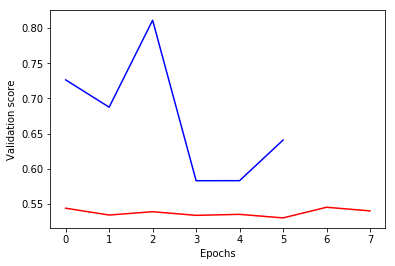

```python
# The input shape to use in the first hidden layer
input_shape = (n_cols,)

# Create the new model: model_1
model_1 = Sequential()
# Add the first and second layers
model_1.add(Dense(50, activation='relu', input_shape=input_shape))
model_1.add(Dense(50, activation='relu'))
# Add the output layer
model_1.add(Dense(2, activation='softmax'))
# Compile model_2
model_1.compile(optimizer='adam', loss='categorical_crossentropy', metrics=['accuracy'])
# Fit model_1
model_1_training = model_1.fit(predictors, target, epochs=15, validation_split=0.2, callbacks=[early_stopping_monitor], verbose=False)


# Create the new model: model_2
model_2 = Sequential()

# Add the first, second, and third hidden layers
model_2.add(Dense(50, activation='relu', input_shape=input_shape))
model_2.add(Dense(50, activation='relu'))
model_2.add(Dense(50, activation='relu'))

# Add the output layer
model_2.add(Dense(2, activation='softmax'))

# Compile model_2
model_2.compile(optimizer='adam', loss='categorical_crossentropy', metrics=['accuracy'])

# Fit model 1
model_1_training = model_1.fit(predictors, target, epochs=20, validation_split=0.4, callbacks=[early_stopping_monitor], verbose=False)

# Fit model 2
model_2_training = model_2.fit(predictors, target, epochs=20, validation_split=0.4, callbacks=[early_stopping_monitor], verbose=False)

# Create the plot
plt.plot(model_1_training.history['val_loss'], 'r', model_2_training.history['val_loss'], 'b')
plt.xlabel('Epochs')
plt.ylabel('Validation score')
plt.show()
```

**Model Capacity is key consideration for deep learning models**

Model Capacity is ability to capture predictive patterns in data. Increasing numbers of nodes, layers etc increases capacity.

Workflow for optimizing model capacity:

1. Start with small network
2. Get the validation score
3. Keep adding capacity as long as the score is improving
4. Experiment

```python
# data = pd.read_csv('https://assets.datacamp.com/production/repositories/654/datasets/24769dae9dc51a77b9baa785d42ea42e3f8f7538/mnist.csv')
```